# Attrition and Salary Case Study

Chance Robinson

12/5/2019

# Introduction

We will explore the case study data to gain insights into employee attrition and salary trends from which will will make predictions from our trained models. Estimating attrition would be considered a classification problem and we’ll be comparing and contrasting model performance based on ROC curves and other accuracy based measures. For the salary predictions, we will be using Linear Regression techniques and grading the model performance based on RMSE (Root Mean Squared Error) and Adjusted R-Squared.

# Exploratory Data Analysis

## Library Imports

```r
# General imports
library(tidyverse)
library(knitr)
library(kableExtra)
```

```r
# Correlation Matrix
library(ggcorrplot)
library(Hmisc)
# KNN
library(class)

# Naive Bayes
library(naivebayes)
# Support Vector Machines
library(e1071)
# Random Forest
library(randomForest)
# downSample
library(caret)
# ROC Curves
library(ROCR)
library(pROC)
# outlier and leverage plots
library(olsrr)
```

## Load the CSV Data

```r
data <- read.csv("../data/CaseStudy2-data.csv", stringsAsFactors=TRUE, header = TRUE)

# data <- read.csv("../data/CaseStudy2-data.csv", stringsAsFactors=TRUE, header = TRUE)
# data <- read.csv("../data/CaseStudy2-data.csv", stringsAsFactors=TRUE, header = TRUE)
```

## Default Output

```r
kable(head(data)) %>%
  kable_styling(bootstrap_options = c("striped", "hover", "condensed", "responsive"))
```

| ID | Age | Attrition | BusinessTravel | DailyRate | Department | DistanceFromHome | Education | EducationField | EmployeeCount | EmployeeNumber | EnvironmentSatisfaction | Gender | HourlyRate | JobInvolvement | JobLevel | JobRole | JobSatisfaction | MaritalStatus | MonthlyIncome | MonthlyRate | NumCompaniesWorked | Over18 | OverTime | PercentSalaryHike | PerformanceRating | RelationshipSatisfaction | StandardHours | StockOptionLevel | TotalWorkingYears | … |
| --- | --- | --- | --- | --- | --- | --- | --- | --- | --- | --- | --- | --- | --- | --- | --- | --- | --- | --- | --- | --- | --- | --- | --- | --- | --- | --- | --- | --- | --- | --- |
| 1 | 32 | No | Travel_Rarely | 117 | Sales | 13 | 4 | Life Sciences | 1 | 859 | 2 | Male | 73 | 3 | 2 | Sales Executive | 4 | Divorced | 4403 | 9250 | 2 | Y | No | 11 | 3 | 3 | 80 | 1 | 8 | … |
| 2 | 40 | No | Travel_Rarely | 1308 | Research & Development | 14 | 3 | Medical | 1 | 1128 | 3 | Male | 44 | 2 | 5 | Research Director | 3 | Single | 19626 | 17544 | 1 | Y | No | 14 | 3 | 1 | 80 | 0 | 21 | … |
| 3 | 35 | No | Travel_Frequently | 200 | Research & Development | 18 | 2 | Life Sciences | 1 | 1412 | 3 | Male | 60 | 3 | 3 | Manufacturing Director | 4 | Single | 9362 | 19944 | 2 | Y | No | 11 | 3 | 3 | 80 | 0 | 10 | … |
| 4 | 32 | No | Travel_Rarely | 801 | Sales | 1 | 4 | Marketing | 1 | 2016 | 3 | Female | 48 | 3 | 3 | Sales Executive | 4 | Married | 10422 | 24032 | 1 | Y | No | 19 | 3 | 3 | 80 | 2 | 14 | … |
| 5 | 24 | No | Travel_Frequently | 567 | Research & Development | 2 | 1 | Technical Degree | 1 | 1646 | 1 | Female | 32 | 3 | 1 | Research Scientist | 4 | Single | 3760 | 17218 | 1 | Y | Yes | 13 | 3 | 3 | 80 | 0 | 6 | … |
| 6 | 27 | No | Travel_Frequently | 294 | Research & Development | 10 | 2 | Life Sciences | 1 | 733 | 4 | Male | 32 | 3 | 3 | Manufacturing Director | 1 | Divorced | 8793 | 4809 | 1 | Y | No | 21 | 4 | 3 | 80 | 2 | 9 | … |

### Identify Dimensions

There are 870 rows and 36 colums in the dataset.

```r
dim(data)
```

```
## [1] 870  36
```

### Data Columns

Here are the column names

```r
colnames(data)
```

```
##  [1] "ID"                       "Age"
##  [3] "Attrition"                "BusinessTravel"
##  [5] "DailyRate"                "Department"
##  [7] "DistanceFromHome"         "Education"
##  [9] "EducationField"           "EmployeeCount"
## [11] "EmployeeNumber"           "EnvironmentSatisfaction"
## [13] "Gender"                   "HourlyRate"
## [15] "JobInvolvement"           "JobLevel"
## [17] "JobRole"                  "JobSatisfaction"
## [19] "MaritalStatus"            "MonthlyIncome"
## [21] "MonthlyRate"              "NumCompaniesWorked"
## [23] "Over18"                   "OverTime"
## [25] "PercentSalaryHike"        "PerformanceRating"
## [27] "RelationshipSatisfaction" "StandardHours"
## [29] "StockOptionLevel"         "TotalWorkingYears"
## [31] "TrainingTimesLastYear"    "WorkLifeBalance"
## [33] "YearsAtCompany"           "YearsInCurrentRole"
## [35] "YearsSinceLastPromotion"  "YearsWithCurrManager"
```

### Convert Integers to Strings

These numeric columns will be converted into strings

```r
data$ID <- as.character(data$ID)
data$EmployeeNumber <- as.character(data$EmployeeNumber)
data$EmployeeCount <- as.character(data$EmployeeCount)
data$StandardHours <- as.character(data$StandardHours)
data$Over18 <- as.character(data$Over18)
```

### Convert Integers to Factors

These integer based columns with be converted into factors.

```r
data$JobInvolvement <- factor(data$JobInvolvement, ordered = TRUE,
                              levels = c(1, 2, 3, 4),
                              labels = c("Low", "Medium", "High", "Very High"))

data$JobSatisfaction <- factor(data$JobSatisfaction, ordered = TRUE,
                              levels = c(1, 2, 3, 4),
                              labels = c("Low", "Medium", "High", "Very High"))

data$PerformanceRating <- factor(data$PerformanceRating, ordered = TRUE,
                              levels = c(1, 2, 3, 4),
                              labels = c("Low", "Good", "Excellent", "Outstanding"))

data$RelationshipSatisfaction <- factor(data$RelationshipSatisfaction, ordered = TRUE,
                              levels = c(1, 2, 3, 4),
                              labels = c("Low", "Medium", "High", "Very High"))

data$WorkLifeBalance <- factor(data$WorkLifeBalance, ordered = TRUE,
                              levels = c(1, 2, 3, 4),
                              labels = c("Bad", "Better", "Good", "Best"))

### THIS WAS NOT ACTUALLY PROVIDED ON THE WALL
data$EnvironmentSatisfaction <- factor(data$EnvironmentSatisfaction, ordered = TRUE,
                              levels = c(1, 2, 3, 4),
                              labels = c("Low", "Medium", "High", "Very High"))

data$StockOptionLevel <- factor(data$StockOptionLevel, ordered = TRUE,
                              levels = c(0, 1, 2, 3),
                              labels = c("Zero", "One", "Two", "Three"))

data$JobLevel <- factor(data$JobLevel, ordered = TRUE,
                              levels = c(1, 2, 3, 4, 5),
                              labels = c("One", "Two", "Three", "Four", "Five"))

data$Education <- factor(data$Education, ordered = FALSE,
                              levels = c(1, 2, 3, 4, 5),
                              labels = c("One", "Two", "Three", "Four", "Five"))
```

### Describe the Data Types

```r
str(data)
```

```
## 'data.frame':    870 obs. of  36 variables:
##  $ ID                      : chr  "1" "2" "3" "4" ...
##  $ Age                     : int  32 40 35 32 24 27 41 37 34 34 ...
##  $ Attrition               : Factor w/ 2 levels "No","Yes": 1 1 1 1 1 1 1 1 1 1 ...
##  $ BusinessTravel          : Factor w/ 3 levels "Non-Travel","Travel_Frequently",..: 3 3 2 3 2 2 3 3 3 2 ...
##  $ DailyRate               : int  117 1308 200 801 567 294 1283 309 1333 653 ...
##  $ Department              : Factor w/ 3 levels "Human Resources",..: 3 2 2 3 2 2 2 3 3 2 ...
##  $ DistanceFromHome        : int  13 14 18 1 2 10 5 10 10 10 ...
##  $ Education               : Factor w/ 5 levels "One","Two","Three",..: 4 3 2 4 1 2 5 4 4 4 ...
##  $ EducationField          : Factor w/ 6 levels "Human Resources",..: 2 4 2 3 6 2 4 2 2 6 ...
##  $ EmployeeCount           : chr  "1" "1" "1" "1" ...
##  $ EmployeeNumber          : chr  "859" "1128" "1412" "2016" ...
##  $ EnvironmentSatisfaction : Ord.factor w/ 4 levels "Low"<"Medium"<..: 2 3 3 3 1 4 2 4 3 4 ...
##  $ Gender                  : Factor w/ 2 levels "Female","Male": 2 2 2 1 1 2 2 1 1 2 ...
##  $ HourlyRate              : int  73 44 60 48 32 32 90 88 87 92 ...
```

[output cut: 22 more lines]

### Numeric Columns

#### Column Names

```r
data.numeric <- data %>%
  select_if(is.numeric)
```

#### Summary Tables

```r
kable(summary(data.numeric)) %>%
  kable_styling(bootstrap_options = c("striped", "hover", "condensed", "responsive"))
```

|  | Age | DailyRate | DistanceFromHome | HourlyRate | MonthlyIncome | MonthlyRate | NumCompaniesWorked | PercentSalaryHike | TotalWorkingYears | TrainingTimesLastYear | YearsAtCompany | YearsInCurrentRole | YearsSinceLastPromotion | YearsWithCurrManager |
| --- | --- | --- | --- | --- | --- | --- | --- | --- | --- | --- | --- | --- | --- | --- |
|  | Min. :18.00 | Min. : 103.0 | Min. : 1.000 | Min. : 30.00 | Min. : 1081 | Min. : 2094 | Min. :0.000 | Min. :11.0 | Min. : 0.00 | Min. :0.000 | Min. : 0.000 | Min. : 0.000 | Min. : 0.000 | Min. : 0.00 |
|  | 1st Qu.:30.00 | 1st Qu.: 472.5 | 1st Qu.: 2.000 | 1st Qu.: 48.00 | 1st Qu.: 2840 | 1st Qu.: 8092 | 1st Qu.:1.000 | 1st Qu.:12.0 | 1st Qu.: 6.00 | 1st Qu.:2.000 | 1st Qu.: 3.000 | 1st Qu.: 2.000 | 1st Qu.: 0.000 | 1st Qu.: 2.00 |
|  | Median :35.00 | Median : 817.5 | Median : 7.000 | Median : 66.00 | Median : 4946 | Median :14074 | Median :2.000 | Median :14.0 | Median :10.00 | Median :3.000 | Median : 5.000 | Median : 3.000 | Median : 1.000 | Median : 3.00 |
|  | Mean :36.83 | Mean : 815.2 | Mean : 9.339 | Mean : 65.61 | Mean : 6390 | Mean :14326 | Mean :2.728 | Mean :15.2 | Mean :11.05 | Mean :2.832 | Mean : 6.962 | Mean : 4.205 | Mean : 2.169 | Mean : 4.14 |
|  | 3rd Qu.:43.00 | 3rd Qu.:1165.8 | 3rd Qu.:14.000 | 3rd Qu.: 83.00 | 3rd Qu.: 8182 | 3rd Qu.:20456 | 3rd Qu.:4.000 | 3rd Qu.:18.0 | 3rd Qu.:15.00 | 3rd Qu.:3.000 | 3rd Qu.:10.000 | 3rd Qu.: 7.000 | 3rd Qu.: 3.000 | 3rd Qu.: 7.00 |
|  | Max. :60.00 | Max. :1499.0 | Max. :29.000 | Max. :100.00 | Max. :19999 | Max. :26997 | Max. :9.000 | Max. :25.0 | Max. :40.00 | Max. :6.000 | Max. :40.000 | Max. :18.000 | Max. :15.000 | Max. :17.00 |

### Plots

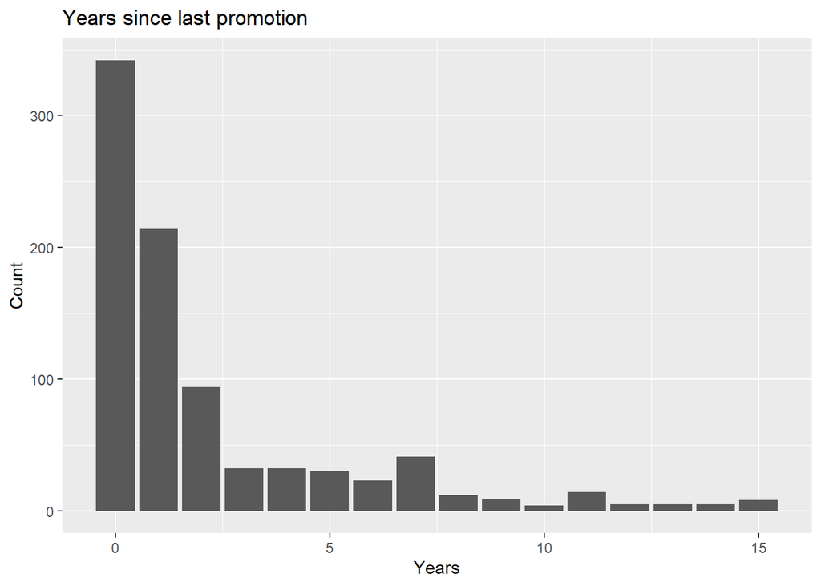

```r
# DistanceFromHome
# NumCompaniesWorked
# TotalWorkingYears
# TrainingTimesLastYear
# YearsAtCompany

ggplot(data=data.numeric, aes(data.numeric$YearsSinceLastPromotion)) +
  geom_bar() +
  ggtitle("Years since last promotion") +
  labs(x = "Years", y = "Count")
```

### Non-Numeric Columns

#### Column Names

```r
data.non.numeric <- data %>%
  select_if(is.factor)

colnames(data.non.numeric)
```

```
##  [1] "Attrition"                "BusinessTravel"
##  [3] "Department"               "Education"
##  [5] "EducationField"           "EnvironmentSatisfaction"
##  [7] "Gender"                   "JobInvolvement"
##  [9] "JobLevel"                 "JobRole"
## [11] "JobSatisfaction"          "MaritalStatus"
## [13] "OverTime"                 "PerformanceRating"
## [15] "RelationshipSatisfaction" "StockOptionLevel"
## [17] "WorkLifeBalance"
```

#### Counts and Percentages

```r
kable(gather(data.non.numeric, "Column", "Value") %>%
  count(Column, Value) %>%
  group_by(Column) %>%
  mutate(Percentage = prop.table(n)) %>%
  rename(Count = n)) %>%
  kable_styling(bootstrap_options = c("striped", "hover", "condensed", "responsive"))
```

| Column | Value | Count | Percentage |
| --- | --- | --- | --- |
| Attrition | No | 730 | 0.8390805 |
| Attrition | Yes | 140 | 0.1609195 |
| BusinessTravel | Non-Travel | 94 | 0.1080460 |
| BusinessTravel | Travel_Frequently | 158 | 0.1816092 |
| BusinessTravel | Travel_Rarely | 618 | 0.7103448 |
| Department | Human Resources | 35 | 0.0402299 |
| Department | Research & Development | 562 | 0.6459770 |
| Department | Sales | 273 | 0.3137931 |
| Education | Five | 26 | 0.0298851 |
| Education | Four | 240 | 0.2758621 |
| Education | One | 98 | 0.1126437 |
| Education | Three | 324 | 0.3724138 |
| Education | Two | 182 | 0.2091954 |
| EducationField | Human Resources | 15 | 0.0172414 |
| EducationField | Life Sciences | 358 | 0.4114943 |
| EducationField | Marketing | 100 | 0.1149425 |
| EducationField | Medical | 270 | 0.3103448 |
| EducationField | Other | 52 | 0.0597701 |
| EducationField | Technical Degree | 75 | 0.0862069 |
| EnvironmentSatisfaction | High | 258 | 0.2965517 |
| EnvironmentSatisfaction | Low | 172 | 0.1977011 |
| EnvironmentSatisfaction | Medium | 178 | 0.2045977 |
| EnvironmentSatisfaction | Very High | 262 | 0.3011494 |
| Gender | Female | 354 | 0.4068966 |
| Gender | Male | 516 | 0.5931034 |
| JobInvolvement | High | 514 | 0.5908046 |
| JobInvolvement | Low | 47 | 0.0540230 |
| JobInvolvement | Medium | 228 | 0.2620690 |
| JobInvolvement | Very High | 81 | 0.0931034 |
| JobLevel | Five | 37 | 0.0425287 |
| JobLevel | Four | 60 | 0.0689655 |
| JobLevel | One | 329 | 0.3781609 |
| JobLevel | Three | 132 | 0.1517241 |
| JobLevel | Two | 312 | 0.3586207 |
| JobRole | Healthcare Representative | 76 | 0.0873563 |
| JobRole | Human Resources | 27 | 0.0310345 |
| JobRole | Laboratory Technician | 153 | 0.1758621 |
| JobRole | Manager | 51 | 0.0586207 |
| JobRole | Manufacturing Director | 87 | 0.1000000 |
| JobRole | Research Director | 51 | 0.0586207 |
| JobRole | Research Scientist | 172 | 0.1977011 |
| JobRole | Sales Executive | 200 | 0.2298851 |
| JobRole | Sales Representative | 53 | 0.0609195 |
| JobSatisfaction | High | 254 | 0.2919540 |
| JobSatisfaction | Low | 179 | 0.2057471 |
| JobSatisfaction | Medium | 166 | 0.1908046 |
| JobSatisfaction | Very High | 271 | 0.3114943 |
| MaritalStatus | Divorced | 191 | 0.2195402 |
| MaritalStatus | Married | 410 | 0.4712644 |
| MaritalStatus | Single | 269 | 0.3091954 |
| OverTime | No | 618 | 0.7103448 |
| OverTime | Yes | 252 | 0.2896552 |
| PerformanceRating | Excellent | 738 | 0.8482759 |
| PerformanceRating | Outstanding | 132 | 0.1517241 |
| RelationshipSatisfaction | High | 261 | 0.3000000 |
| RelationshipSatisfaction | Low | 174 | 0.2000000 |
| RelationshipSatisfaction | Medium | 171 | 0.1965517 |
| RelationshipSatisfaction | Very High | 264 | 0.3034483 |
| StockOptionLevel | One | 355 | 0.4080460 |
| StockOptionLevel | Three | 55 | 0.0632184 |
| StockOptionLevel | Two | 81 | 0.0931034 |
| StockOptionLevel | Zero | 379 | 0.4356322 |
| WorkLifeBalance | Bad | 48 | 0.0551724 |
| WorkLifeBalance | Best | 98 | 0.1126437 |
| WorkLifeBalance | Better | 192 | 0.2206897 |
| WorkLifeBalance | Good | 532 | 0.6114943 |

### Correlation matrix for quantitative data

```r
# function for flattening and ordering the correlation matrix
flattenCorrMatrix <- function(cormat, pmat) {
  ut <- upper.tri(cormat)
  data.frame(
    row = rownames(cormat)[row(cormat)[ut]],
    column = rownames(cormat)[col(cormat)[ut]],
    correlation  =(cormat)[ut],
    p.value = pmat[ut]
    )
}
# See what variables are correlated with each other, p-values
correlation.matrix <- rcorr(as.matrix(data.numeric))
corDF <- data.frame(flattenCorrMatrix(correlation.matrix$r, correlation.matrix$P))
# Order the correlation matrix to show the highest correlated
# data.frame(corDF[order(-corDF$cor),])

quantDataModel <- corDF[which(abs(corDF$correlation) >= 0.5),]

kable(data.frame(quantDataModel[order(-abs(quantDataModel$cor)),])) %>%
  kable_styling(bootstrap_options = c("striped", "hover", "condensed", "responsive"))
```

|  | row | column | correlation | p.value |
| --- | --- | --- | --- | --- |
| 33 | MonthlyIncome | TotalWorkingYears | 0.7785112 | 0 |
| 66 | YearsAtCompany | YearsInCurrentRole | 0.7761164 | 0 |
| 89 | YearsAtCompany | YearsWithCurrManager | 0.7652262 | 0 |
| 90 | YearsInCurrentRole | YearsWithCurrManager | 0.7094612 | 0 |
| 29 | Age | TotalWorkingYears | 0.6526131 | 0 |
| 77 | YearsAtCompany | YearsSinceLastPromotion | 0.6440298 | 0 |
| 54 | TotalWorkingYears | YearsAtCompany | 0.6360836 | 0 |
| 78 | YearsInCurrentRole | YearsSinceLastPromotion | 0.5537100 | 0 |
| 91 | YearsSinceLastPromotion | YearsWithCurrManager | 0.5089354 | 0 |

### Correlation Plot

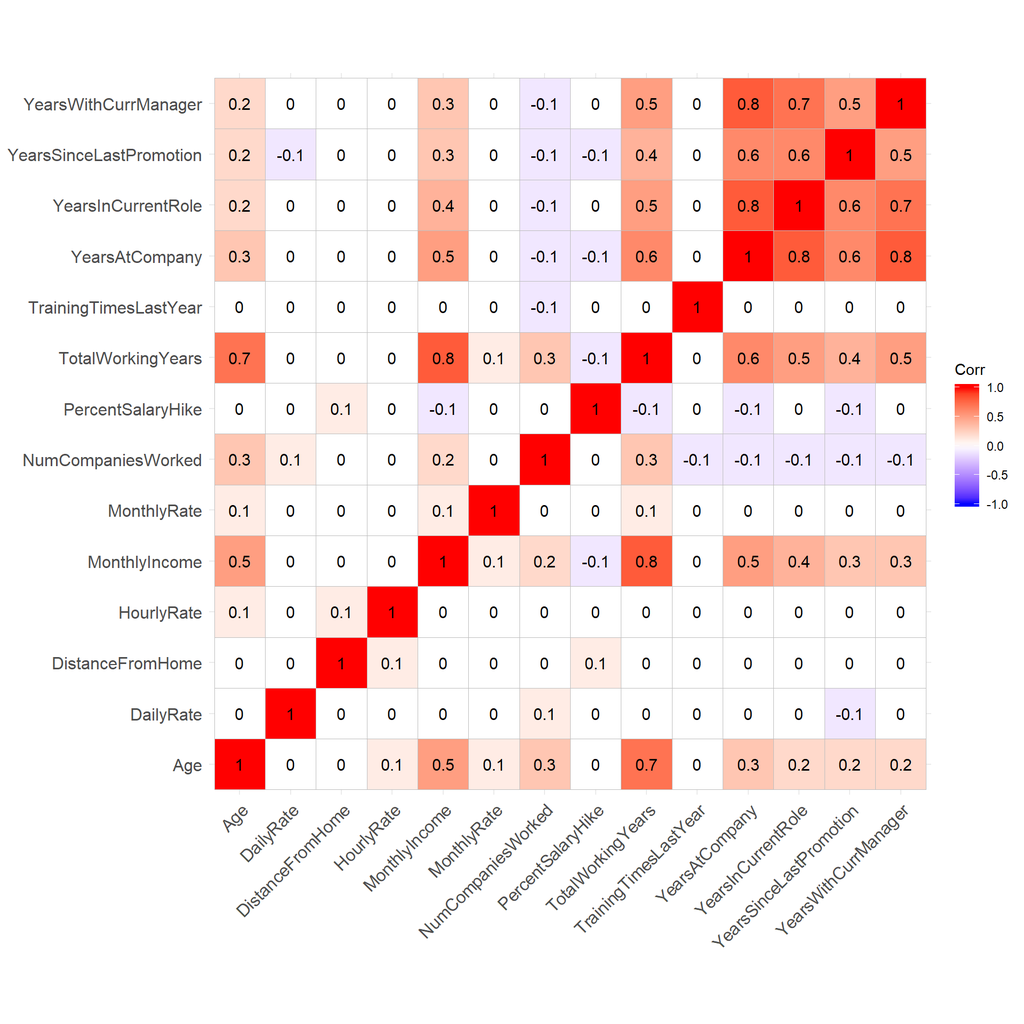

```r
correlation.plot <- round(cor(data.numeric), 1)
ggcorrplot(correlation.plot, method = "square", type = "full", lab = TRUE)
```

# Objective I

Model Comparisons for Attrition classification

## KNN

### Prepare Dataframe

```r
cols_to_keep = c("YearsSinceLastPromotion", "YearsWithCurrManager", "TrainingTimesLastYear", "DistanceFromHome", "NumCompaniesWorked", "YearsInCurrentRole", "TotalWorkingYears", "JobInvolvement", "OverTime", "BusinessTravel", "Attrition")

cols_to_remove <- c("ID", "EmployeeNumber", "EmployeeCount", "StandardHours", "Over18")

data.mod <- data %>%
  select(cols_to_keep)

# head(data.mod)
```

### Train / Test Split

```r
set.seed(1234)

sample.data <- sample_frac(data.mod, 1)

split.perc = .70

train.indices = sample(1:dim(sample.data)[1],round(split.perc * dim(sample.data)[1]))

train = sample.data[train.indices,]
test = sample.data[-train.indices,]

train <- upSample(train, as.factor(train$Attrition), list = FALSE)
train$Class <- NULL

# library(DMwR)
# train <- SMOTE(Attrition ~ ., train, perc.over = 100, perc.under=200)
```

### Build the model

```r
set.seed(1234)
ctrl <- trainControl(method="cv")
knn.model <- train(Attrition ~ ., data = train, method = "knn", trControl = ctrl, preProcess = c("center","scale"), tuneLength = 10)

knn.model
```

```
## k-Nearest Neighbors
##
## 1016 samples
##   10 predictor
##    2 classes: 'No', 'Yes'
##
## Pre-processing: centered (13), scaled (13)
## Resampling: Cross-Validated (10 fold)
## Summary of sample sizes: 914, 915, 914, 915, 915, 915, ...
## Resampling results across tuning parameters:
##
##   k   Accuracy   Kappa
##    5  0.7440982  0.4882561
##    7  0.7322559  0.4644946
##    9  0.7382353  0.4764856
##   11  0.7520384  0.5040723
##   13  0.7509610  0.5019075
##   15  0.7569113  0.5139042
##   17  0.7490099  0.4979955
##   19  0.7411279  0.4821626
##   21  0.7263638  0.4526977
##   23  0.7233741  0.4467560
##
## Accuracy was used to select the optimal model using the largest value.
## The final value used for the model was k = 15.
```

### Make predictions

```r
knn.predict <- predict(knn.model, newdata = test)
```

### Test Performance

```r
confusionMatrix(knn.predict, test$Attrition, "Yes")
```

```
## Confusion Matrix and Statistics
##
##           Reference
## Prediction  No Yes
##        No  167  12
##        Yes  55  27
##
##                Accuracy : 0.7433
##                  95% CI : (0.6858, 0.7952)
##     No Information Rate : 0.8506
##     P-Value [Acc > NIR] : 1
##
##                   Kappa : 0.3057
##
##  Mcnemar's Test P-Value : 2.88e-07
##
##             Sensitivity : 0.6923
##             Specificity : 0.7523
##          Pos Pred Value : 0.3293
##          Neg Pred Value : 0.9330
##              Prevalence : 0.1494
##          Detection Rate : 0.1034
##    Detection Prevalence : 0.3142
##       Balanced Accuracy : 0.7223
##
##        'Positive' Class : Yes
##
```

### Area Under the Curve

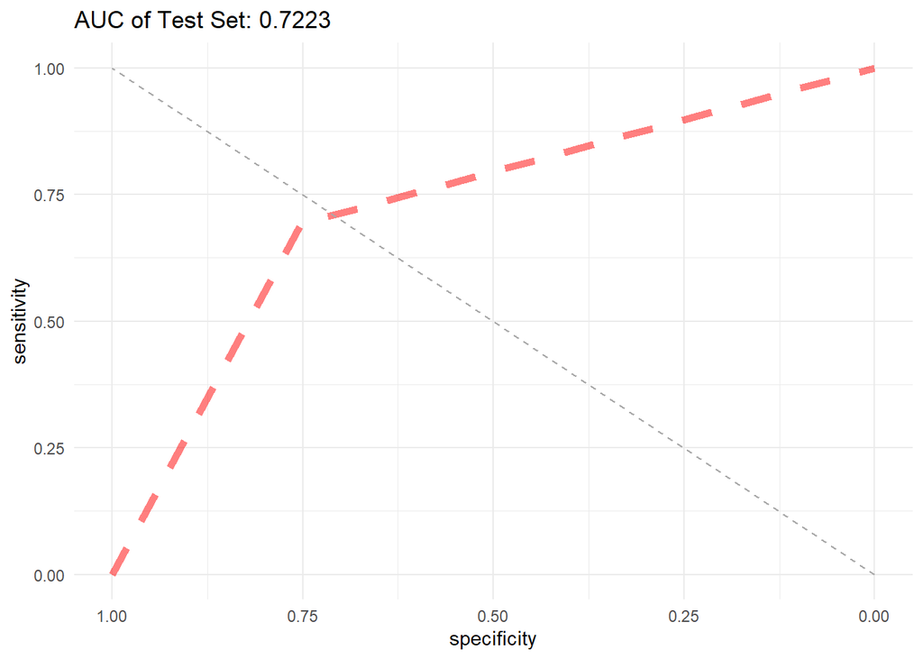

```r
# ?pROC

auc <- roc(as.integer(test$Attrition), as.integer(knn.predict))


g <- ggroc(auc, alpha = 0.5, colour = "red", linetype = 2, size = 2) +
  theme_minimal() +
  ggtitle(paste('AUC of Test Set:', round(auc$auc[[1]],4))) +
  geom_segment(aes(x = 0, xend = 1, y = 0, yend = 1), color="darkgrey", linetype="dashed")


plot(g)
```

## Prepare Dataframe

```r
cols_to_remove <- c("ID", "EmployeeNumber", "EmployeeCount", "StandardHours", "Over18")


data.mod <- data %>%
  select(-cols_to_remove) %>%
  mutate(Attrition = factor(Attrition, labels = c("No", "Yes")))

# summary(data.mod)
```

### Train / Test Split

```r
set.seed(1234)

sample.data <- sample_frac(data.mod, 1)

split.perc = .70

train.indices = sample(1:dim(sample.data)[1],round(split.perc * dim(sample.data)[1]))

train = sample.data[train.indices,]
test = sample.data[-train.indices,]

train <- upSample(train, as.factor(train$Attrition), list = FALSE)
train$Class <- NULL

# library(DMwR)
# train <- SMOTE(Attrition ~ ., train, perc.over = 100, perc.under=200)
```

### Build the model

```r
model.nb.train <- naive_bayes(Attrition ~ ., data = train, laplace = TRUE, usekernel = TRUE)
```

### Make predictions

```r
p1 <- predict(model.nb.train, train)
p2 <- predict(model.nb.train, test)
```

### Test Performance

```r
confusionMatrix(data=p2,
                reference=test$Attrition, "Yes")
```

```
## Confusion Matrix and Statistics
##
##           Reference
## Prediction  No Yes
##        No  158  11
##        Yes  64  28
##
##                Accuracy : 0.7126
##                  95% CI : (0.6536, 0.7668)
##     No Information Rate : 0.8506
##     P-Value [Acc > NIR] : 1
##
##                   Kappa : 0.2754
##
##  Mcnemar's Test P-Value : 1.92e-09
##
##             Sensitivity : 0.7179
##             Specificity : 0.7117
##          Pos Pred Value : 0.3043
##          Neg Pred Value : 0.9349
##              Prevalence : 0.1494
##          Detection Rate : 0.1073
##    Detection Prevalence : 0.3525
##       Balanced Accuracy : 0.7148
##
##        'Positive' Class : Yes
##
```

### Area Under the Curve

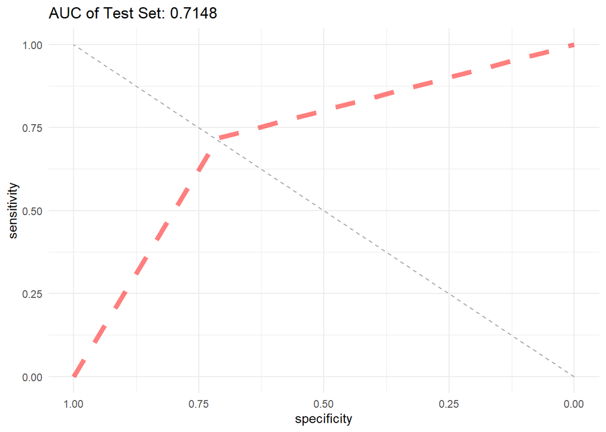

```r
# ?pROC

auc <- roc(as.integer(test$Attrition), as.integer(p2))


g <- ggroc(auc, alpha = 0.5, colour = "red", linetype = 2, size = 2) +
  theme_minimal() +
  ggtitle(paste('AUC of Test Set:', round(auc$auc[[1]],4))) +
  geom_segment(aes(x = 0, xend = 1, y = 0, yend = 1), color="darkgrey", linetype="dashed")


plot(g)
```

## Logistic Regression

### Prepare Dataframe

```r
cols_to_remove <- c("ID", "EmployeeNumber", "EmployeeCount", "StandardHours", "Over18")


data.mod <- data %>%
  select(-cols_to_remove) %>%
  mutate(Attrition = factor(Attrition, labels = c("No", "Yes")))

# summary(data.mod)

# str(data.mod)
```

## Train / Test Split

```r
set.seed(1234)

sample.data <- sample_frac(data.mod, 1)

split.perc = .70

train.indices = sample(1:dim(sample.data)[1],round(split.perc * dim(sample.data)[1]))

train = sample.data[train.indices,]
test = sample.data[-train.indices,]

train <- upSample(train, as.factor(train$Attrition), list = FALSE)
train$Class <- NULL

# library(DMwR)
# train <- SMOTE(Attrition ~ ., train, perc.over = 100, perc.under=200)
```

### Build the model

```r
lg.model <- glm(Attrition~DistanceFromHome+JobInvolvement+OverTime+BusinessTravel+NumCompaniesWorked+WorkLifeBalance+EnvironmentSatisfaction+YearsSinceLastPromotion+YearsWithCurrManager+TrainingTimesLastYear, data = train, family = binomial("logit"))
summary(lg.model)
```

```
##
## Call:
## glm(formula = Attrition ~ DistanceFromHome + JobInvolvement +
##     OverTime + BusinessTravel + NumCompaniesWorked + WorkLifeBalance +
##     EnvironmentSatisfaction + YearsSinceLastPromotion + YearsWithCurrManager +
##     TrainingTimesLastYear, family = binomial("logit"), data = train)
##
## Deviance Residuals:
##     Min       1Q   Median       3Q      Max
## -3.1330  -0.7515  -0.0037   0.7400   2.4545
##
## Coefficients:
##                                  Estimate Std. Error z value Pr(>|z|)
## (Intercept)                     -1.306889   0.429522  -3.043 0.002345 **
## DistanceFromHome                 0.060319   0.009357   6.446 1.15e-10 ***
## JobInvolvement.L                -1.501131   0.279874  -5.364 8.16e-08 ***
## JobInvolvement.Q                 0.763350   0.231932   3.291 0.000997 ***
## JobInvolvement.C                 0.043293   0.154838   0.280 0.779784
## OverTimeYes                      1.699470   0.173361   9.803  < 2e-16 ***
## BusinessTravelTravel_Frequently  1.733107   0.370370   4.679 2.88e-06 ***
## BusinessTravelTravel_Rarely      1.096741   0.336320   3.261 0.001110 **
## NumCompaniesWorked               0.054291   0.032471   1.672 0.094526 .
## WorkLifeBalance.L               -1.703038   0.269222  -6.326 2.52e-10 ***
## WorkLifeBalance.Q                0.595273   0.226205   2.632 0.008499 **
## WorkLifeBalance.C               -0.248960   0.163147  -1.526 0.127014
## EnvironmentSatisfaction.L       -0.287499   0.160339  -1.793 0.072962 .
## EnvironmentSatisfaction.Q        1.054188   0.172954   6.095 1.09e-09 ***
## EnvironmentSatisfaction.C       -0.478558   0.176596  -2.710 0.006730 **
## YearsSinceLastPromotion          0.158845   0.033640   4.722 2.34e-06 ***
## YearsWithCurrManager            -0.284032   0.033917  -8.374  < 2e-16 ***
## TrainingTimesLastYear           -0.054926   0.066043  -0.832 0.405597
## ---
## Signif. codes:  0 '***' 0.001 '**' 0.01 '*' 0.05 '.' 0.1 ' ' 1
##
## (Dispersion parameter for binomial family taken to be 1)
##
##     Null deviance: 1408.48  on 1015  degrees of freedom
## Residual deviance:  969.75  on  998  degrees of freedom
## AIC: 1005.8
##
## Number of Fisher Scoring iterations: 5
```

### Make predictions

```r
test$predict <- predict(lg.model, test, type="response")
test$predict <- as.factor(ifelse(test$predict >0.45, "Yes", "No"))
```

### Test performance

```r
confusionMatrix(data=test$predict,
                reference=test$Attrition, "Yes")
```

```
## Confusion Matrix and Statistics
##
##           Reference
## Prediction  No Yes
##        No  153  12
##        Yes  69  27
##
##                Accuracy : 0.6897
##                  95% CI : (0.6297, 0.7453)
##     No Information Rate : 0.8506
##     P-Value [Acc > NIR] : 1
##
##                   Kappa : 0.2381
##
##  Mcnemar's Test P-Value : 4.902e-10
##
##             Sensitivity : 0.6923
##             Specificity : 0.6892
##          Pos Pred Value : 0.2813
##          Neg Pred Value : 0.9273
##              Prevalence : 0.1494
##          Detection Rate : 0.1034
##    Detection Prevalence : 0.3678
##       Balanced Accuracy : 0.6907
##
##        'Positive' Class : Yes
##
```

### Area Under the Curve

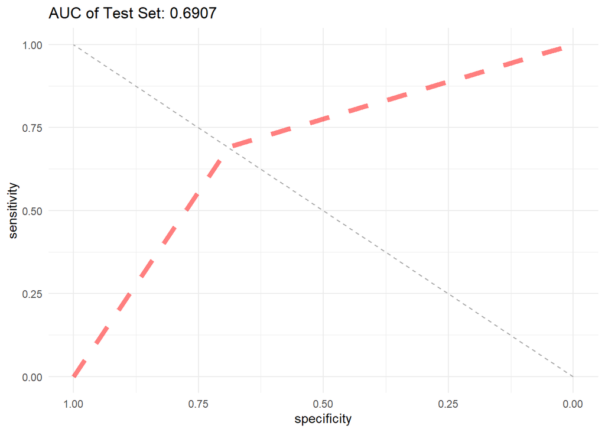

```r
# ?pROC

auc <- roc(as.integer(test$Attrition), as.integer(test$predict))


g <- ggroc(auc, alpha = 0.5, colour = "red", linetype = 2, size = 2) +
  theme_minimal() +
  ggtitle(paste('AUC of Test Set:', round(auc$auc[[1]],4))) +
  geom_segment(aes(x = 0, xend = 1, y = 0, yend = 1), color="darkgrey", linetype="dashed")


plot(g)
```

## Support Vector Machines

### Prepare Dataframe

```r
cols_to_remove <- c("ID", "EmployeeNumber", "EmployeeCount", "StandardHours", "Over18")


data.mod <- data %>%
  select(-cols_to_remove) %>%
  mutate(Attrition = factor(Attrition, labels = c("No", "Yes")))

# summary(data.mod)
```

### Train / Test Split

```r
set.seed(1234)

sample.data <- sample_frac(data.mod, 1)

split.perc = .70

train.indices = sample(1:dim(sample.data)[1],round(split.perc * dim(sample.data)[1]))

train = sample.data[train.indices,]
test = sample.data[-train.indices,]

# train <- upSample(train, as.factor(train$Attrition), list = FALSE)
# train$Class <- NULL

library(DMwR)
train <- SMOTE(Attrition ~ ., train, perc.over = 100, perc.under=200)
```

### Build the model

```r
sum <- sum(table(test$Attrition))
wts <- table(test$Attrition) / sum

wts
```

```
##
##        No       Yes
## 0.8505747 0.1494253
```

```r
svm.model <- svm(Attrition ~ .,
           data = train,
           cost = 4,
           class.weights= c("No" = 0.4, "Yes" = 1),
           scale=TRUE
           )


summary(svm.model)
```

```
##
## Call:
## svm(formula = Attrition ~ ., data = train, cost = 4, class.weights = c(No = 0.4,
##     Yes = 1), scale = TRUE)
##
##
## Parameters:
##    SVM-Type:  C-classification
##  SVM-Kernel:  radial
##        cost:  4
##
## Number of Support Vectors:  221
##
##  ( 146 75 )
##
##
## Number of Classes:  2
##
## Levels:
##  No Yes
```

### Make predictions

```r
prd <- predict(svm.model, test)
```

### Test performance

```r
confusionMatrix(data=prd,
                reference=test$Attrition, "Yes")
```

```
## Confusion Matrix and Statistics
##
##           Reference
## Prediction  No Yes
##        No  168  10
##        Yes  54  29
##
##                Accuracy : 0.7548
##                  95% CI : (0.698, 0.8057)
##     No Information Rate : 0.8506
##     P-Value [Acc > NIR] : 1
##
##                   Kappa : 0.3415
##
##  Mcnemar's Test P-Value : 7.658e-08
##
##             Sensitivity : 0.7436
##             Specificity : 0.7568
##          Pos Pred Value : 0.3494
##          Neg Pred Value : 0.9438
##              Prevalence : 0.1494
##          Detection Rate : 0.1111
##    Detection Prevalence : 0.3180
##       Balanced Accuracy : 0.7502
##
##        'Positive' Class : Yes
##
```

### Area Under the Curve

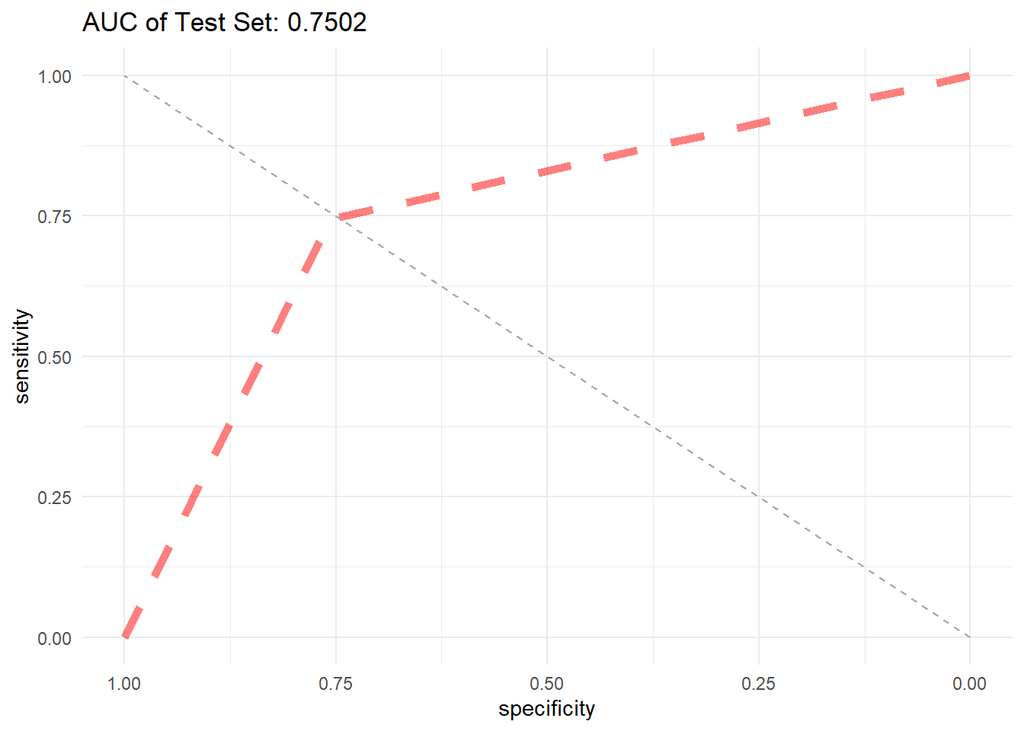

```r
# ?pROC

auc <- roc(as.integer(test$Attrition), as.integer(prd))


g <- ggroc(auc, alpha = 0.5, colour = "red", linetype = 2, size = 2) +
  theme_minimal() +
  ggtitle(paste('AUC of Test Set:', round(auc$auc[[1]],4))) +
  geom_segment(aes(x = 0, xend = 1, y = 0, yend = 1), color="darkgrey", linetype="dashed")


plot(g)
```

## Random Forrest

### Prepare Dataframe

```r
data <- read.csv("../data/CaseStudy2-data.csv", stringsAsFactors=TRUE, header = TRUE)

data$ID <- as.character(data$ID)
data$EmployeeNumber <- as.character(data$EmployeeNumber)
data$EmployeeCount <- as.character(data$EmployeeCount)
data$StandardHours <- as.character(data$StandardHours)
data$Over18 <- as.character(data$Over18)


cols_to_remove <- c("ID", "EmployeeNumber", "EmployeeCount", "StandardHours", "Over18")


data.mod <- data %>%
  select(-cols_to_remove) %>%
  mutate(Attrition = factor(Attrition, labels = c("No", "Yes")))


# summary(data.mod)
```

### Train / Test Split

```r
set.seed(1234)

split.perc = .70

train.indices = sample(1:dim(data.mod)[1],round(split.perc * dim(data.mod)[1]))

train = data.mod[train.indices,]
test = data.mod[-train.indices,]

# UPSAMPLING
# train <- upSample(train, train$Attrition, list = FALSE)
# train$Class <- NULL

library(DMwR)
train <- SMOTE(Attrition ~ ., train, perc.over = 100, perc.under=200)

# head(train)
```

### Build the model

```r
model.rf.train <- randomForest(Attrition ~ .,
                               data = train,
                               ntree = 150,
                               mtry = 10,
                               cutoff = c(0.55,1-0.55)
                               )

print(model.rf.train)
```

```
##
## Call:
##  randomForest(formula = Attrition ~ ., data = train, ntree = 150,      mtry = 10, cutoff = c(0.55, 1 - 0.55))
##                Type of random forest: classification
##                      Number of trees: 150
## No. of variables tried at each split: 10
##
##         OOB estimate of  error rate: 14.13%
## Confusion matrix:
##      No Yes class.error
## No  151  33   0.1793478
## Yes  19 165   0.1032609
```

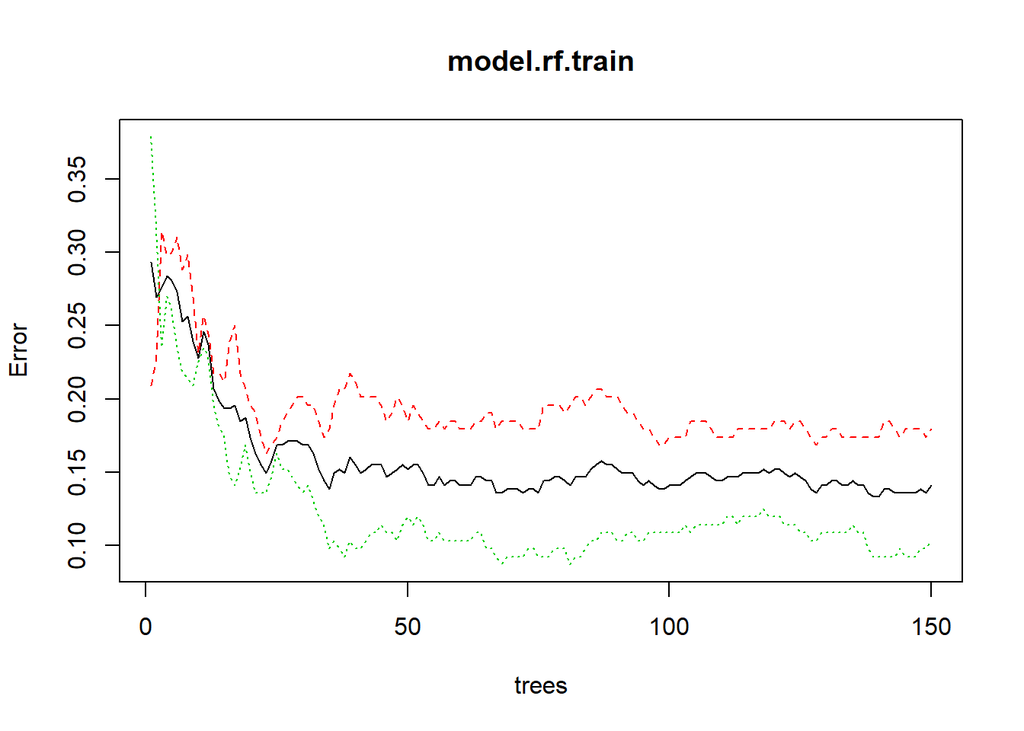

```r
# ?na.action


p1 <- predict(model.rf.train, train, type="response")
p2 <- predict(model.rf.train, test, type="response")


plot(model.rf.train)
```

```r
varImp(model.rf.train)
```

```
##                             Overall
## Age                       9.0890540
## BusinessTravel            1.3705516
## DailyRate                 7.8551889
## Department                1.0640864
## DistanceFromHome          8.9292815
## Education                 4.3056564
## EducationField            4.2239012
## EnvironmentSatisfaction   3.7245123
## Gender                    0.5300156
## HourlyRate                6.7244875
## JobInvolvement            5.9251385
## JobLevel                  6.8126250
## JobRole                  15.9546174
## JobSatisfaction           5.8223348
## MaritalStatus             1.6230747
## MonthlyIncome             7.9595825
## MonthlyRate               5.2806506
## NumCompaniesWorked        4.6104161
## OverTime                 13.8470130
## PercentSalaryHike         4.2710465
## PerformanceRating         0.6615489
## RelationshipSatisfaction  3.7029147
## StockOptionLevel         28.5685343
## TotalWorkingYears         5.3838001
## TrainingTimesLastYear     6.6222193
## WorkLifeBalance           3.6871380
## YearsAtCompany            4.8731321
## YearsInCurrentRole        3.1571317
## YearsSinceLastPromotion   4.0245629
## YearsWithCurrManager      2.8796603
```

```r
# head(train)
```

### Make predictions

```r
prd <- predict(model.rf.train, test)
```

### Test performance

```r
confusionMatrix(data=prd,
                reference=test$Attrition, "Yes")
```

```
## Confusion Matrix and Statistics
##
##           Reference
## Prediction  No Yes
##        No  159  13
##        Yes  54  35
##
##                Accuracy : 0.7433
##                  95% CI : (0.6858, 0.7952)
##     No Information Rate : 0.8161
##     P-Value [Acc > NIR] : 0.9986
##
##                   Kappa : 0.3574
##
##  Mcnemar's Test P-Value : 1.025e-06
##
##             Sensitivity : 0.7292
##             Specificity : 0.7465
##          Pos Pred Value : 0.3933
##          Neg Pred Value : 0.9244
##              Prevalence : 0.1839
##          Detection Rate : 0.1341
##    Detection Prevalence : 0.3410
##       Balanced Accuracy : 0.7378
##
##        'Positive' Class : Yes
##
```

### Area Under the Curve

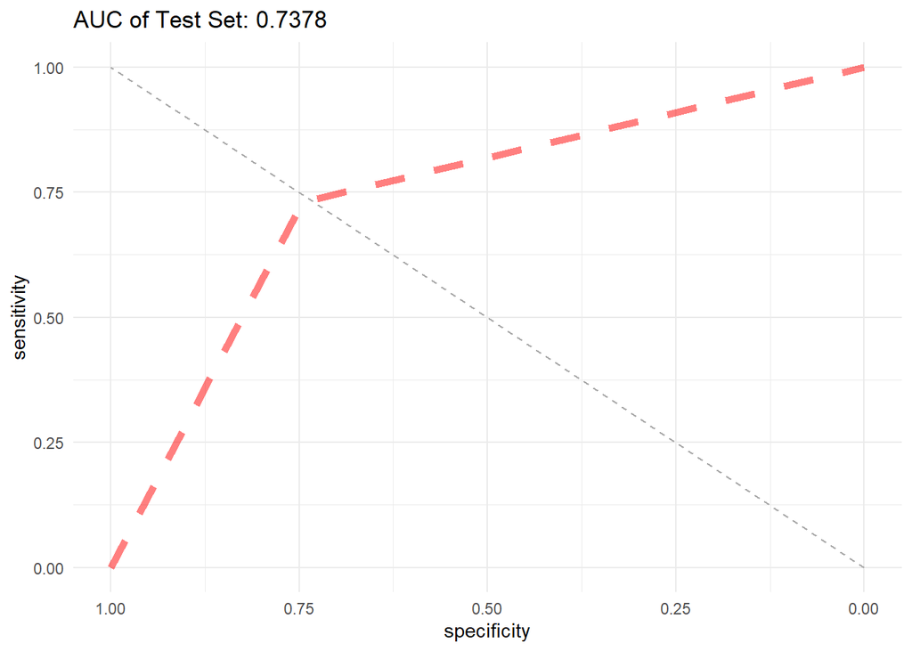

```r
# ?pROC

auc <- roc(as.integer(test$Attrition), as.integer(prd))


g <- ggroc(auc, alpha = 0.5, colour = "red", linetype = 2, size = 2) +
  theme_minimal() +
  ggtitle(paste('AUC of Test Set:', round(auc$auc[[1]],4))) +
  geom_segment(aes(x = 0, xend = 1, y = 0, yend = 1), color="darkgrey", linetype="dashed")


plot(g)
```

### Tune Performance

```r
# tuneRF(train[,-2], train[,2],
#        stepFactor = 0.5,
#        ntreeTry = 150,
#        trace = TRUE,
#        improve = 0.5
# )
```

# Objective II

Salary Predictions

## Multiple Linear Regression

### Load the CSV Data

```r
data <- read.csv("../data/CaseStudy2-data.csv", stringsAsFactors=TRUE, header = TRUE)
```

```r
data$ID <- as.character(data$ID)
data$EmployeeNumber <- as.character(data$EmployeeNumber)
data$EmployeeCount <- as.character(data$EmployeeCount)
data$StandardHours <- as.character(data$StandardHours)
data$Over18 <- as.character(data$Over18)
```

### Convert Integers to Factors

```r
data$JobInvolvement <- factor(data$JobInvolvement, ordered = TRUE,
                              levels = c(1, 2, 3, 4),
                              labels = c("Low", "Medium", "High", "Very High"))

data$JobSatisfaction <- factor(data$JobSatisfaction, ordered = TRUE,
                              levels = c(1, 2, 3, 4),
                              labels = c("Low", "Medium", "High", "Very High"))

data$PerformanceRating <- factor(data$PerformanceRating, ordered = TRUE,
                              levels = c(1, 2, 3, 4),
                              labels = c("Low", "Good", "Excellent", "Outstanding"))

data$RelationshipSatisfaction <- factor(data$RelationshipSatisfaction, ordered = TRUE,
                              levels = c(1, 2, 3, 4),
                              labels = c("Low", "Medium", "High", "Very High"))

data$WorkLifeBalance <- factor(data$WorkLifeBalance, ordered = TRUE,
                              levels = c(1, 2, 3, 4),
                              labels = c("Bad", "Better", "Good", "Best"))

### THIS WAS NOT ACTUALLY PROVIDED ON THE WALL
data$EnvironmentSatisfaction <- factor(data$EnvironmentSatisfaction, ordered = TRUE,
                              levels = c(1, 2, 3, 4),
                              labels = c("Low", "Medium", "High", "Very High"))

data$StockOptionLevel <- factor(data$StockOptionLevel, ordered = TRUE,
                              levels = c(0, 1, 2, 3),
                              labels = c("Zero", "One", "Two", "Three"))

data$JobLevel <- factor(data$JobLevel, ordered = TRUE,
                              levels = c(1, 2, 3, 4, 5),
                              labels = c("One", "Two", "Three", "Four", "Five"))

data$Education <- factor(data$Education, ordered = FALSE,
                              levels = c(1, 2, 3, 4, 5),
                              labels = c("One", "Two", "Three", "Four", "Five"))
```

## Prepare Dataframe

```r
cols_to_remove <- c("ID", "EmployeeNumber", "EmployeeCount", "StandardHours", "Over18")


data.mod <- data %>%
  select(-cols_to_remove) %>%
  mutate(Attrition = factor(Attrition, labels = c("No", "Yes"))) %>%
  filter(!row_number() %in% c(753L, 376L, 350L)) # remove outliers

# summary(data.mod)
```

## Train / Test Split

```r
set.seed(1234)

sample.data <- sample_frac(data.mod, 1)

split.perc = .70

train.indices = sample(1:dim(sample.data)[1],round(split.perc * dim(sample.data)[1]))

train = sample.data[train.indices,]
test = sample.data[-train.indices,]
```

```r
## Outliers
# data[753, ]
# data[376, ]
# data[350, ]

lm.model.full <- lm(MonthlyIncome~., data = train)
summary(lm.model.full)
```

```
##
## Call:
## lm(formula = MonthlyIncome ~ ., data = train)
##
## Residuals:
##     Min      1Q  Median      3Q     Max
## -3162.5  -615.0   -25.5   544.9  4190.6
##
## Coefficients:
##                                    Estimate Std. Error t value Pr(>|t|)
## (Intercept)                       7.946e+03  7.763e+02  10.236  < 2e-16 ***
## Age                              -2.283e-01  6.749e+00  -0.034  0.97302
## AttritionYes                      1.515e+01  1.382e+02   0.110  0.91275
## BusinessTravelTravel_Frequently   2.175e+02  1.698e+02   1.281  0.20084
## BusinessTravelTravel_Rarely       3.584e+02  1.430e+02   2.506  0.01250 *
## DailyRate                         1.849e-01  1.087e-01   1.700  0.08963 .
## DepartmentResearch & Development  3.143e+02  5.240e+02   0.600  0.54892
## DepartmentSales                  -2.105e+02  5.475e+02  -0.384  0.70078
## DistanceFromHome                 -5.546e-01  5.513e+00  -0.101  0.91990
## EducationTwo                      3.292e+01  1.653e+02   0.199  0.84222
## EducationThree                   -4.323e+01  1.503e+02  -0.288  0.77380
## EducationFour                     1.818e+02  1.601e+02   1.135  0.25672
## EducationFive                    -1.478e+02  3.182e+02  -0.464  0.64258
## EducationFieldLife Sciences       2.660e+02  4.632e+02   0.574  0.56599
## EducationFieldMarketing           1.991e+02  4.877e+02   0.408  0.68319
## EducationFieldMedical             2.209e+02  4.640e+02   0.476  0.63420
## EducationFieldOther              -8.420e+01  4.965e+02  -0.170  0.86540
## EducationFieldTechnical Degree    9.837e+01  4.789e+02   0.205  0.83732
## EnvironmentSatisfaction.L        -4.889e+01  8.850e+01  -0.552  0.58090
## EnvironmentSatisfaction.Q        -8.423e+00  8.879e+01  -0.095  0.92446
## EnvironmentSatisfaction.C         4.332e+01  8.949e+01   0.484  0.62854
## GenderMale                        1.902e+01  8.903e+01   0.214  0.83094
## HourlyRate                       -2.036e+00  2.199e+00  -0.926  0.35487
## JobInvolvement.L                 -3.700e+01  1.620e+02  -0.228  0.81939
## JobInvolvement.Q                  1.181e+02  1.326e+02   0.891  0.37357
## JobInvolvement.C                  3.946e+00  8.599e+01   0.046  0.96341
## JobLevel.L                        9.046e+03  3.293e+02  27.472  < 2e-16 ***
## JobLevel.Q                        5.953e+02  1.760e+02   3.382  0.00077 ***
## JobLevel.C                       -7.524e+02  1.473e+02  -5.108 4.52e-07 ***
## JobLevel^4                        7.629e+01  1.273e+02   0.599  0.54938
```

[output cut: 24 more lines]

```
## TotalWorkingYears                 4.027e+01  1.366e+01   2.949  0.00333 **
## TrainingTimesLastYear             5.208e+01  3.529e+01   1.476  0.14056
## WorkLifeBalance.L                 5.049e+01  1.521e+02   0.332  0.74005
## WorkLifeBalance.Q                -1.156e+02  1.240e+02  -0.932  0.35153
## WorkLifeBalance.C                -1.408e+01  8.736e+01  -0.161  0.87199
## YearsAtCompany                    2.105e+00  1.660e+01   0.127  0.89914
## YearsInCurrentRole                8.455e+00  2.012e+01   0.420  0.67451
## YearsSinceLastPromotion           2.481e+01  1.935e+01   1.282  0.20042
## YearsWithCurrManager             -1.769e+01  1.973e+01  -0.897  0.37016
## ---
## Signif. codes:  0 '***' 0.001 '**' 0.01 '*' 0.05 '.' 0.1 ' ' 1
##
## Residual standard error: 1030 on 544 degrees of freedom
## Multiple R-squared:  0.9567, Adjusted R-squared:  0.9518
## F-statistic: 193.9 on 62 and 544 DF,  p-value: < 2.2e-16
```

```r
lm.model.reduced <- lm(MonthlyIncome~BusinessTravel+DailyRate+JobLevel+JobRole+TotalWorkingYears, data = train)
summary(lm.model.reduced)
```

```
##
## Call:
## lm(formula = MonthlyIncome ~ BusinessTravel + DailyRate + JobLevel +
##     JobRole + TotalWorkingYears, data = train)
##
## Residuals:
##     Min      1Q  Median      3Q     Max
## -3239.5  -660.0   -53.8   578.9  4102.5
##
## Coefficients:
##                                   Estimate Std. Error t value Pr(>|t|)
## (Intercept)                      8487.5162   277.6992  30.564  < 2e-16 ***
## BusinessTravelTravel_Frequently   231.6010   161.7454   1.432 0.152706
## BusinessTravelTravel_Rarely       360.7165   136.1821   2.649 0.008295 **
## DailyRate                           0.1517     0.1029   1.473 0.141258
## JobLevel.L                       9039.2931   307.0800  29.436  < 2e-16 ***
## JobLevel.Q                        583.7690   159.0654   3.670 0.000265 ***
## JobLevel.C                       -761.6744   134.1662  -5.677 2.15e-08 ***
## JobLevel^4                         67.7816   119.4982   0.567 0.570781
## JobRoleHuman Resources          -1134.1843   320.1521  -3.543 0.000427 ***
## JobRoleLaboratory Technician    -1390.4939   210.9280  -6.592 9.62e-11 ***
## JobRoleManager                   3145.8423   284.8850  11.042  < 2e-16 ***
## JobRoleManufacturing Director    -114.4014   192.3727  -0.595 0.552281
## JobRoleResearch Director         3206.4263   252.4223  12.703  < 2e-16 ***
## JobRoleResearch Scientist       -1142.7033   219.3259  -5.210 2.61e-07 ***
## JobRoleSales Executive            -90.5150   164.9326  -0.549 0.583350
## JobRoleSales Representative     -1326.0996   267.0809  -4.965 9.00e-07 ***
## TotalWorkingYears                  49.7851     9.6402   5.164 3.30e-07 ***
## ---
## Signif. codes:  0 '***' 0.001 '**' 0.01 '*' 0.05 '.' 0.1 ' ' 1
##
## Residual standard error: 1014 on 590 degrees of freedom
## Multiple R-squared:  0.9544, Adjusted R-squared:  0.9532
## F-statistic: 772.1 on 16 and 590 DF,  p-value: < 2.2e-16
```

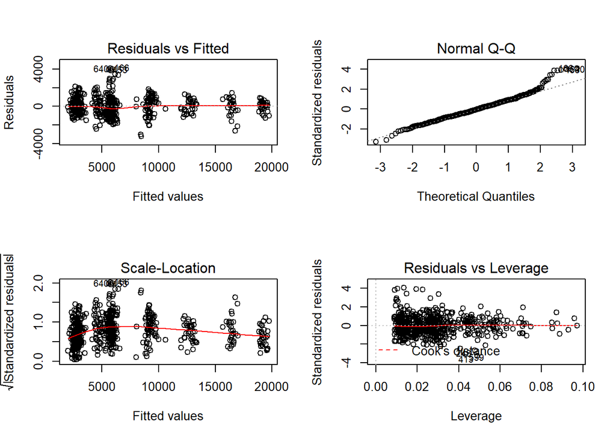

```r
par(mfrow=c(2,2))
plot(lm.model.reduced)
```

### Test

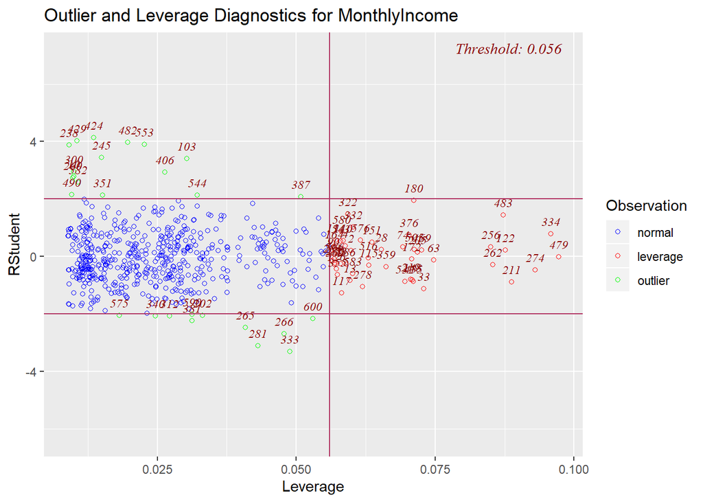

```r
ols_plot_resid_lev(lm.model.reduced)
```

### Outliers

```r
# Outliers
kable(data[c(753, 376, 350), ]) %>%
  kable_styling(bootstrap_options = c("striped", "hover", "condensed", "responsive"))
```

|  | ID | Age | Attrition | BusinessTravel | DailyRate | Department | DistanceFromHome | Education | EducationField | EmployeeCount | EmployeeNumber | EnvironmentSatisfaction | Gender | HourlyRate | JobInvolvement | JobLevel | JobRole | JobSatisfaction | MaritalStatus | MonthlyIncome | MonthlyRate | NumCompaniesWorked | Over18 | OverTime | PercentSalaryHike | PerformanceRating | RelationshipSatisfaction | StandardHours | StockOptionLevel | … |
| --- | --- | --- | --- | --- | --- | --- | --- | --- | --- | --- | --- | --- | --- | --- | --- | --- | --- | --- | --- | --- | --- | --- | --- | --- | --- | --- | --- | --- | --- | --- |
| 753 | 753 | 50 | No | Travel_Frequently | 1234 | Research & Development | 20 | Five | Medical | 1 | 1606 | Medium | Male | 41 | High | Four | Healthcare Representative | High | Married | 11245 | 20689 | 2 | Y | Yes | 15 | Excellent | High | 80 | One | … |
| 376 | 376 | 50 | No | Travel_Frequently | 333 | Research & Development | 22 | Five | Medical | 1 | 1539 | High | Male | 88 | Low | Four | Research Director | Very High | Single | 14411 | 24450 | 1 | Y | Yes | 13 | Excellent | Very High | 80 | Zero | … |
| 350 | 350 | 56 | No | Travel_Rarely | 832 | Research & Development | 9 | Three | Medical | 1 | 762 | High | Male | 81 | High | Four | Healthcare Representative | Very High | Married | 11103 | 20420 | 7 | Y | No | 11 | Excellent | High | 80 | Zero | … |

### Performance Metrics

```r
## cross validate the full model
# Set up k-fold cross-validation
train.control <- trainControl(method = "cv", number = 10)


model.full.formula <- MonthlyIncome ~ .
model.reduced.formula <- MonthlyIncome ~ BusinessTravel+DailyRate+JobLevel+JobRole+TotalWorkingYears


# # Train the full model
# model.full.cv <- train(model.full.formula,
#                     data = data.mod,
#                     method = 'lm',
#                     trControl = train.control)
# # print model summary
# model.full.cv
#
#
# ## cross validate the reduced model
# # Set up k-fold cross-validation
# train.control <- trainControl(method = "cv", number = 10)
# # Train the model
# model.reduced.cv <- train(model.reduced.formula,
#                     data = data.mod,
#                     method = 'lm',
#                     trControl = train.control)
#
# # print model summary
# model.reduced.cv



train.model.reduced.cv <- train(model.reduced.formula,
                    data = train,
                    method = 'lm',
                    trControl = train.control)

# print model summary
train.model.reduced.cv
```

```
## Linear Regression
##
## 607 samples
##   5 predictor
##
## No pre-processing
## Resampling: Cross-Validated (10 fold)
## Summary of sample sizes: 545, 547, 547, 547, 546, 546, ...
## Resampling results:
##
##   RMSE      Rsquared   MAE
##   1023.318  0.9480504  784.6031
##
## Tuning parameter 'intercept' was held constant at a value of TRUE
```

```r
# Train the model
test.model.reduced.cv <- train(model.reduced.formula,
                    data = test,
                    method = 'lm',
                    trControl = train.control)

# print model summary
test.model.reduced.cv
```

```
## Linear Regression
##
## 260 samples
##   5 predictor
##
## No pre-processing
## Resampling: Cross-Validated (10 fold)
## Summary of sample sizes: 233, 234, 235, 235, 234, 234, ...
## Resampling results:
##
##   RMSE      Rsquared   MAE
##   968.4481  0.9451278  753.2718
##
## Tuning parameter 'intercept' was held constant at a value of TRUE
```

# Conclusion

Model Performance surprisingly was not substantially different between the classification models that were reviewed. Machine Learning algorithms can outperform classical models even with relatively small data sets as we saw with our 870 observations. (split between train and test data sets with a 70/30 ratio) Cross Validation was also instrumental in our ability to control for overfitting as we generally saw unrealistic performance outcomes with using only the training data set to validate against.